# Homework Template

Merai Dandouch

September 08, 2024

Please use this template to generate results for the tasks (see [rmarkdown.rstudio.com/](https://rmarkdown.rstudio.com)), or the closest equivalent if you are using Quarto. In particular, each Task should start with a level 1 heading:

# Differential Analysis: Carcinogens vs. non-Carcinogens

```r
library(Biobase)
library(limma)
library(pheatmap)
library(ComplexHeatmap)
```

## Uploading and Inspecting the Data

Load object ExpressionSet which is a multi-faceted data object containing:

1. exprs (p x n)
2. annotation pData (n x k)
3. annotation fData (p x m)

where:

- n = samples
- p = genes
- m = features/gene annotations
- k = phenotype annotations

```r
dm10 <- readRDS(file.path(getwd(), "dm10.RDS"))
dim(dm10)
```

```
## Features  Samples
##     9682      338
```

pdata stores the experimental (phenotype) conditions …

```r
# show the annotation of a few samples
tail(pData(dm10))
```

```
##               CHEMICAL      DOSE DURATION SEX Carcinogen_liv GenTox
## 96107.CEL TESTOSTERONE 375 mg/kg      3 d   M     CARCINOGEN      0
## 96088.CEL TESTOSTERONE 375 mg/kg      3 d   M     CARCINOGEN      0
## 96101.CEL TESTOSTERONE 375 mg/kg      3 d   M     CARCINOGEN      0
## 96093.CEL TESTOSTERONE 375 mg/kg      5 d   M     CARCINOGEN      0
## 96089.CEL TESTOSTERONE 375 mg/kg      5 d   M     CARCINOGEN      0
## 96104.CEL TESTOSTERONE 375 mg/kg      5 d   M     CARCINOGEN      0
```

fdata stores the gene annotations …

```r
# show the annotation of a few samples
tail(fData(dm10))
```

```
##                         OldID           description
## ACLY    ENSRNOG00000016924_at ENSRNOG00000016924_at
## ANKRD12 ENSRNOG00000012733_at ENSRNOG00000012733_at
## DYNLRB2 ENSRNOG00000012450_at ENSRNOG00000012450_at
## MRS2    ENSRNOG00000017545_at ENSRNOG00000017545_at
## HMBS    ENSRNOG00000010390_at ENSRNOG00000010390_at
## FLOT2   ENSRNOG00000009681_at ENSRNOG00000009681_at
```

```r
# show chemicals of a few samples
head(table(pData(dm10)$CHEMICAL))
```

```
##
##                                     2,3,7,8-TETRACHLORODIBENZO-P-DIOXIN
##                                 225                                   9
##                       ACETAMINOPHEN                             ASPIRIN
##                                   3                                  24
##                            DIAZEPAM                         DOXORUBICIN
##                                   8                                  21
```

Check to see which samples were exposed to highly carcinogenic conditions vs not

```r
# show chemicals of a few samples
table(pData(dm10)$Carcinogen_liv, useNA="ifany")
```

```
##
##   NON-CARC CARCINOGEN       <NA>
##         63         50        225
```

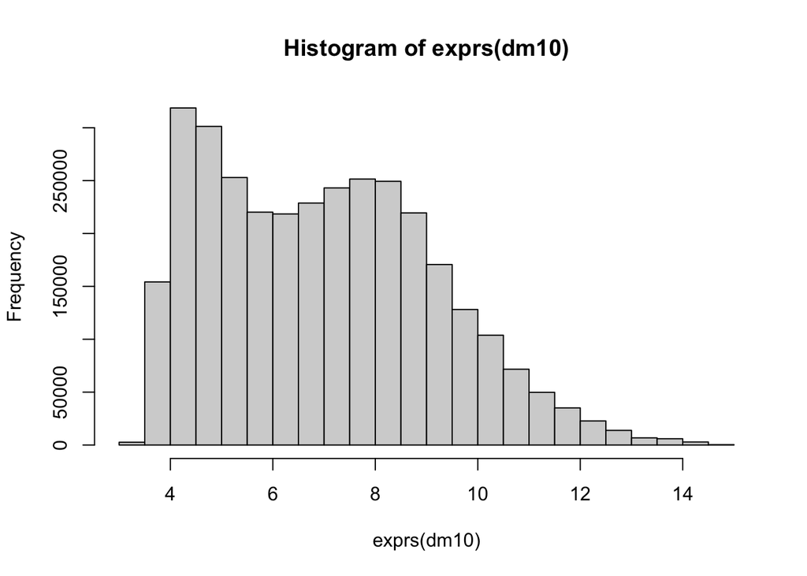

```r
## let us simplify the phenotype name for easier handling
colnames(pData(dm10)) <- gsub( "Carcinogen_liv", "carc", colnames(pData(dm10)) )
## show the expression data (across all samples and genes)
hist(exprs(dm10))
```

Data doesn’t seem to be normalized …?

**Remember:**

- that dm10 exprs dimensions are p x n so samples are on the columns! and p are gene names which are rownames in the dataset exprs().
- but then those samples are actually rows in annotated pData (n x k)

So the code is doing as follows:

1. Filter exprs dataset to include samples (or cols) ONLY containing contain non-car and car values and filter out controls. It’s kind of confusing to think about, but the sample columns we are filtering out, are the rows in pData. Ultimately, we are removing samples that are controls.
2. Filter exprs dataset to exclude samples that have NUll values in GenTox column of pData. Similar execution to the above statement.
3. Order will tell you the indices of ascending values, thus we organize the dataset so that samples are ordered by increasing carc values such as ( NON-CARC, …, CARCINOGEN, CARCINOGEN)

```r
dat <- dm10[ ,pData(dm10)$carc %in% c('NON-CARC', 'CARCINOGEN')]

dat <- dat[ ,!is.na(pData(dat)$GenTox)]

#sort increasingly
#dat <- dat[ ,order(dat$carc, decreasing=TRUE)]
dat <- dat[ ,order(dat$carc)]

pData(dat)[,"carc"]
```

```
##   [1] NON-CARC   NON-CARC   NON-CARC   NON-CARC   NON-CARC   NON-CARC
##   [7] NON-CARC   NON-CARC   NON-CARC   NON-CARC   NON-CARC   NON-CARC
##  [13] NON-CARC   NON-CARC   NON-CARC   NON-CARC   NON-CARC   NON-CARC
##  [19] NON-CARC   NON-CARC   NON-CARC   NON-CARC   NON-CARC   NON-CARC
##  [25] NON-CARC   NON-CARC   NON-CARC   NON-CARC   NON-CARC   NON-CARC
##  [31] NON-CARC   NON-CARC   NON-CARC   NON-CARC   NON-CARC   NON-CARC
##  [37] NON-CARC   NON-CARC   NON-CARC   NON-CARC   NON-CARC   NON-CARC
##  [43] NON-CARC   NON-CARC   NON-CARC   NON-CARC   NON-CARC   NON-CARC
##  [49] NON-CARC   NON-CARC   NON-CARC   NON-CARC   NON-CARC   NON-CARC
##  [55] NON-CARC   NON-CARC   NON-CARC   NON-CARC   NON-CARC   NON-CARC
##  [61] NON-CARC   NON-CARC   NON-CARC   CARCINOGEN CARCINOGEN CARCINOGEN
##  [67] CARCINOGEN CARCINOGEN CARCINOGEN CARCINOGEN CARCINOGEN CARCINOGEN
##  [73] CARCINOGEN CARCINOGEN CARCINOGEN CARCINOGEN CARCINOGEN CARCINOGEN
##  [79] CARCINOGEN CARCINOGEN CARCINOGEN CARCINOGEN CARCINOGEN CARCINOGEN
##  [85] CARCINOGEN CARCINOGEN CARCINOGEN CARCINOGEN CARCINOGEN CARCINOGEN
##  [91] CARCINOGEN CARCINOGEN CARCINOGEN CARCINOGEN CARCINOGEN CARCINOGEN
##  [97] CARCINOGEN CARCINOGEN CARCINOGEN CARCINOGEN CARCINOGEN CARCINOGEN
## [103] CARCINOGEN CARCINOGEN
## Levels: NON-CARC CARCINOGEN
```

## Variation Filtering

MAD is the median absolute deviation (in other words, its the distance between observations and the mean).

Using apply we can filter highly variable genes (longest average distance from median), where exprs(dat) is p x n dataset and median() and mad() will be applied to all p (rows)

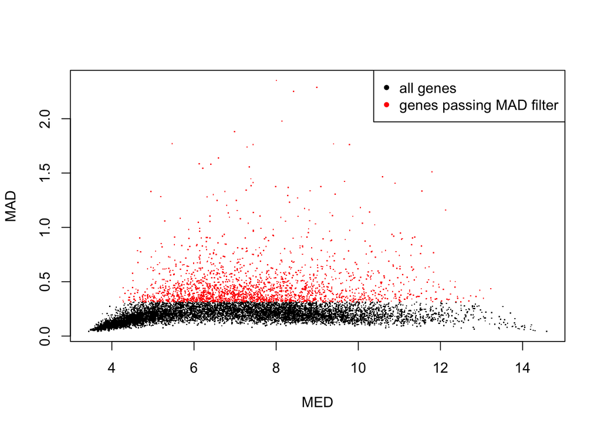

```r
MED <- apply(exprs(dat), 1, median)
MAD <- apply(exprs(dat), 1, mad)
top.genes <- order(MAD,decreasing=TRUE)[1:2000] # order increasingly...

plot(MED,MAD,pch=".",log="")
points(MED[top.genes],MAD[top.genes],pch=".",col='red')
legend("topright",pch=20,col=c('black','red'),legend=c("all genes","genes passing MAD filter"))
```

```r
## dat is the filtered data to be used henceforth (and carc the phenotype)
dat <- dat[top.genes,]
```

# Task 1: Diffanal with t.test assuming unequal variance (var.equal=FALSE)

Next, make use of the t.test function, ideally, in the t.test(gene ~ phenotype) version. Use the option var.equal, and see how the results differ, and see which of the two analyses (with var.equal=FALSE or var.equal=TRUE) yields equivalent results to those obtained with the lm function, to be used next.

```r
# script to evaluate each gene in dat by t.test
# perform t-test for each sample
y <- pData(dat)[,"carc"]

calc_ttest <- function(x) {
  tt <- t.test(x ~ y, var.equal=FALSE)
  return(c(t.score = tt$statistic, t.pvalue = tt$p.value))
}

ttestRes0 <- apply(exprs(dat), 1, calc_ttest)
ttestRes0 <- as.data.frame(t(ttestRes0))
ttestRes0$t.fdr <- p.adjust(ttestRes0$t.pvalue, method = "BH")

head(ttestRes0)
```

```
##         t.score.t     t.pvalue       t.fdr
## UBD     1.1402299 0.2574663659 0.430751402
## STAC3   0.4849606 0.6291174476 0.767216399
## SDS     3.7755092 0.0002692987 0.003095387
## BCL6    1.0837669 0.2815896990 0.455278414
## NPAS2  -2.9261148 0.0042495363 0.021921700
## CCRN4L -0.3695677 0.7126956494 0.822499307
```

# Task 2:Diffanal with t.test assuming equal variance (var.equal=TRUE)

Perform t.test with equal variance on all genes, adjust p-values by FDR procedure (BH method), and save the output in a data.frame named ttestRes1.

```r
# script to evaluate each gene in dat by t.test
# perform t-test for each sample
y <- pData(dat)[,"carc"]

calc_ttest <- function(x) {
  tt <- t.test(x ~ y, var.equal=TRUE)
  return(c(t.score = tt$statistic, t.pvalue = tt$p.value))
}

ttestRes1 <- apply(exprs(dat), 1, calc_ttest)
ttestRes1 <- as.data.frame(t(ttestRes1))
ttestRes1$t.fdr <- p.adjust(ttestRes1$t.pvalue, method = "BH")

head(ttestRes1)
```

```
##         t.score.t     t.pvalue       t.fdr
## UBD     1.1501773 0.2527603328 0.425164563
## STAC3   0.5031098 0.6159717375 0.760527246
## SDS     3.5090763 0.0006706304 0.005474534
## BCL6    1.0919120 0.2774441994 0.450396428
## NPAS2  -2.7564829 0.0069228112 0.030164755
## CCRN4L -0.3783172 0.7059811620 0.818528883
```

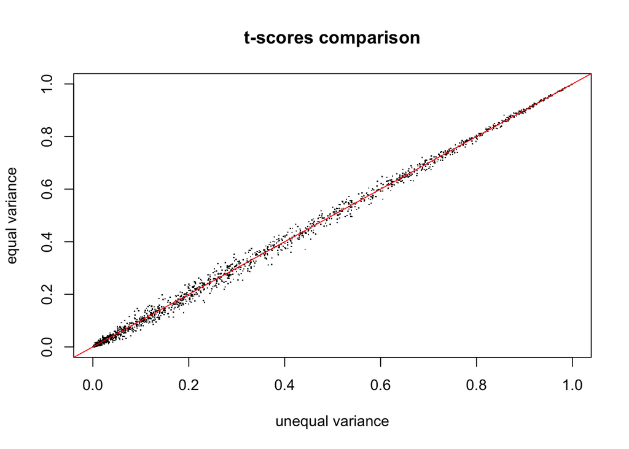

```r
## plot p-values and t-statistics of var.equal=FALSE against var.equal=TRUE
plot(ttestRes0[,'t.pvalue'],ttestRes1[,'t.pvalue'],pch=".",
     xlab="unequal variance",ylab="equal variance",main='t-scores comparison')
abline(0,1,col='red')
```

# Task 3: Diffanal using lm w/o confounders

Next, we will use the lm function, and compare the results to those obtained using the t.test function (see above). After computing the lm-based t-scores and p-values (and FDR-adjusted q-values), we will plot them against the t.test-based ones (one or the other is sufficient).

**REMEMBER :** Outcome Variable X = Genes

Predictor Variable Y = Carc vs Non-Carc

```r
# script to evaluate each gene in dat by lm
## the format of the output object should be as follows
## Note: the 'lm.score' column corresponds to the 't value' parameter
## ..returned by the summary(lm(...)) function

y <- pData(dat)[,"carc"]

lm_test <- function(x) {
  dat_lm <- lm(x ~ y)
  dat_lm <- summary(dat_lm)
  lm.tvalue <- dat_lm$coefficient["yCARCINOGEN","t value"]
  lm.pvalue <- dat_lm$coefficient["yCARCINOGEN","Pr(>|t|)"]
  return(c("lm.score" = lm.tvalue, "lm.pvalue" = lm.pvalue))
}

lmRes0 <- apply(exprs(dat), 1, lm_test)
lmRes0 <- as.data.frame(t(lmRes0)) #transpose dataset
lmRes0$lm.fdr <- p.adjust(lmRes0$lm.pvalue, method = "BH")
```

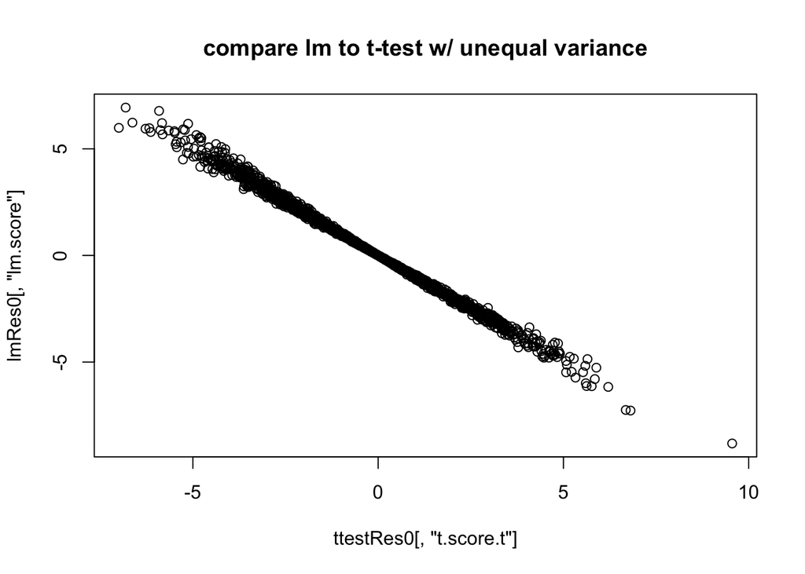

```r
## plot lm-based statistics against t.test-based statistics
plot(ttestRes0[,"t.score.t"],lmRes0[,"lm.score"],main="compare lm to t-test w/ unequal variance")
```

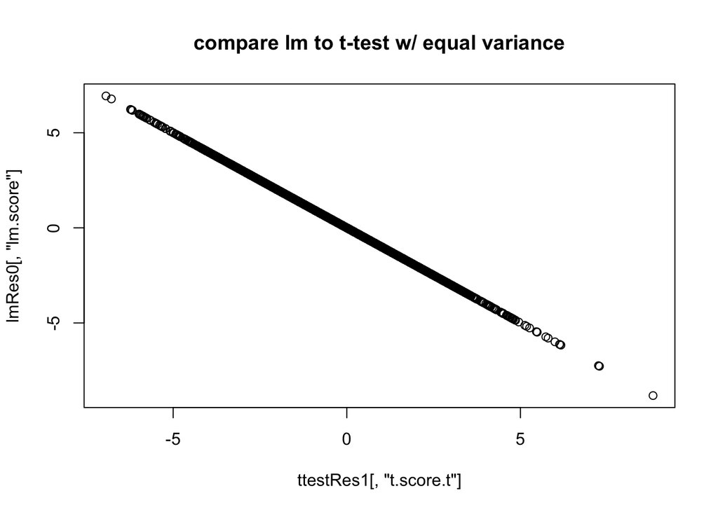

```r
plot(ttestRes1[,"t.score.t"],lmRes0[,"lm.score"],main="compare lm to t-test w/ equal variance")
```

# Task 4: Controlling for confounders

Perform differential analysis based on the lm function, while controlling for the confounding effect of genotoxicity, and save the output in a data.frame named lmRes1. Basically, we repeat the analysis controlling for the potentially confounding effect of the genotoxicity status of the compounds (stored in pData(dat)$GenTox).

*NOTE*:Genotoxicity refers to ability of a chemical to do signiciant damage to genetic material and are usually binary numbers (0 or 1) denoting if it is damaging vs not damaging.

```r
## count number of genotoxic samples
table(pData(dat)$GenTox,useNA="ifany")
```

```
##
##  0  1
## 83 21
```

```r
## let's see how carcinogens and genotoxicants are distributed
table(pData(dat)[,c("carc","GenTox")])
```

```
##             GenTox
## carc          0  1
##   NON-CARC   42 21
##   CARCINOGEN 41  0
```

```r
## lmRes1 <- <script to evaluate each gene in dat by lm w/ confounder>

y <- pData(dat)[,"carc"]
gen_tox <- pData(dat)[, "GenTox"]

lm_test <- function(x) {
  dat_lm <- lm(x ~ y + gen_tox)
  dat_lm <- summary(dat_lm)
  lm.tvalue <- dat_lm$coefficient["yCARCINOGEN","t value"]
  lm.pvalue <- dat_lm$coefficient["yCARCINOGEN","Pr(>|t|)"]
  return(c("lm.score" = lm.tvalue, "lm.pvalue" = lm.pvalue))
}

lmRes1 <- apply(exprs(dat), 1, lm_test)
lmRes1 <- as.data.frame(t(lmRes1)) #transpose dataset
lmRes1$lm.fdr <- p.adjust(lmRes1$lm.pvalue, method = "BH")
```

```r
head(lmRes1)
```

```
##          lm.score lm.pvalue    lm.fdr
## UBD    -0.9448016 0.3470149 0.5852186
## STAC3   0.5229368 0.6021636 0.7845779
## SDS    -1.5615506 0.1215219 0.3289455
## BCL6   -0.2884261 0.7736116 0.8897201
## NPAS2   0.4688074 0.6402177 0.8129748
## CCRN4L  0.8491627 0.3977990 0.6315532
```

```r
lm0.markers <- lmRes0[,"lm.fdr"]<=0.05
lm1.markers <- lmRes1[,"lm.fdr"]<=0.05
print(sum(lm0.markers))
```

```
## [1] 522
```

```r
print(sum(lm1.markers))
```

```
## [1] 275
```

**Next, we compare the two results. Which analysis returns the largest number of significant genes, and why?**

- Summary: * Looking at the effects of chemicals on gene expression using a linear model with no confounding variables returns the largest number of significant genes. However, that doesn’t mean it’s the best model.

**REMEMBER:**

- x, dependent, response, outcome = genes
- y, independent, term, predictor = carcinogenic vs non-carc
- confounding = Gen-tox

Applying a linear_model(x ~ y) against the data where genes (x) is the response vector and carc data (y) are the terms which specifies a linear predictor for the response only considers the relationship between genes and chemicals that are carcinogenic vs not carcinogenic. However, when adding a confounding effect to the linear model, we are providing the model more information about the effects of chemicals on gene expression (dependent variable) and introducing less bias to the outcome. Just because a chemical might be carcinogenic, does not mean it would cause damage to DNA and cause a gene to be differentially expressed. Adding Gen-Toxicity confounding values lets us know that the effect of carcinogenic chemicals on gene expression is not biased. Therefore, the model that gave us more highly variable genes is the first model with no confounding variables but the model with less bias is the second model with a confounding variable.

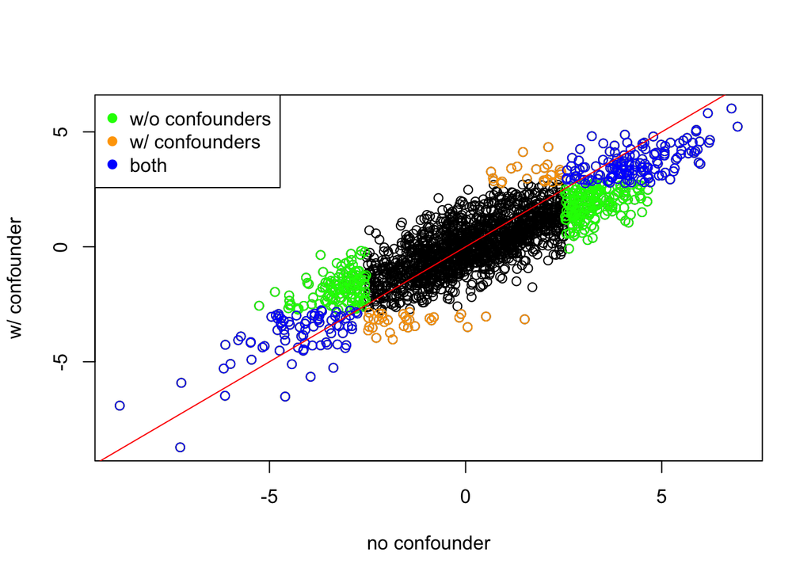

```r
## compare the scores returned by the two analyses
lm0.markers <- lmRes0[,"lm.fdr"]<=0.05
lm1.markers <- lmRes1[,"lm.fdr"]<=0.05
lm.markers <- lm0.markers & lm1.markers
plot(lmRes0[,'lm.score'],lmRes1[,'lm.score'],xlab="no confounder",ylab="w/ confounder")
points(lmRes0[lm0.markers,'lm.score'],lmRes1[lm0.markers,'lm.score'],col="green")
points(lmRes0[lm1.markers,'lm.score'],lmRes1[lm1.markers,'lm.score'],col="orange")
points(lmRes0[lm.markers,'lm.score'],lmRes1[lm.markers,'lm.score'],col="blue")
abline(0,1,col="red")
legend("topleft",col=c("green","orange","blue"), pch=19,
       legend=c("w/o confounders","w/ confounders","both"))
```

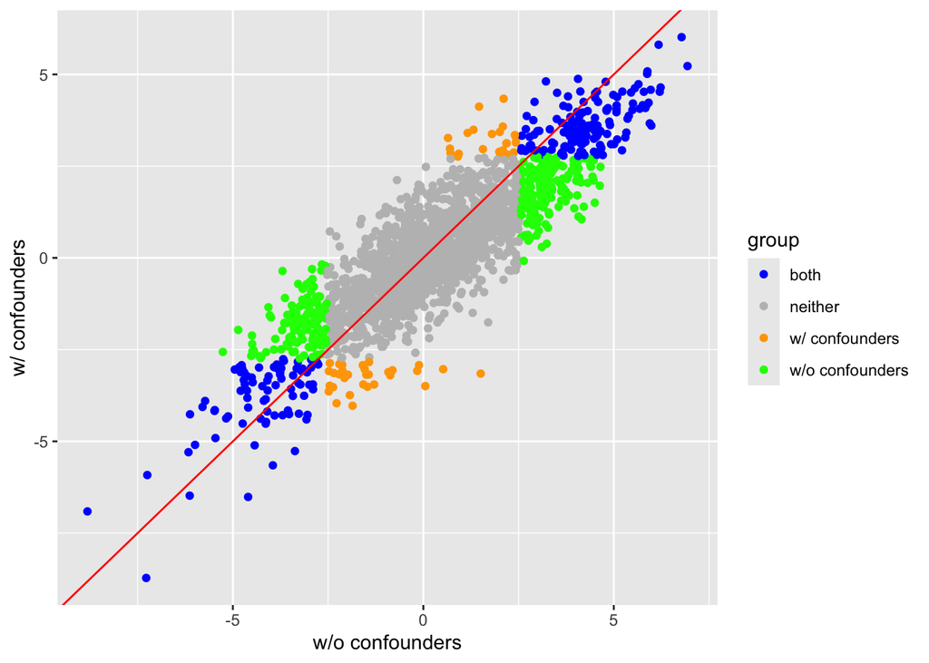

```r
library(ggplot2)
library(dplyr)
maxQ <- 0.05
DFlm <- dplyr::inner_join(as.data.frame(lmRes0) %>% tibble::rownames_to_column(),
                          as.data.frame(lmRes1) %>% tibble::rownames_to_column(),
                          by="rowname",suffix=c(".0",".1")) %>%
  tibble::column_to_rownames() %>%
  dplyr::mutate(group=ifelse(lm.fdr.0<=maxQ & lm.fdr.1<=maxQ,"both",
                             ifelse(lm.fdr.0<=maxQ,"w/o confounders",
                                    ifelse(lm.fdr.1<=maxQ,"w/ confounders","neither"))))
COL <- c(neither="gray",
         "w/o confounders"="green",
         "w/ confounders"="orange",
         both="blue")
ggplot2::ggplot(DFlm,aes(x=lm.score.0,y=lm.score.1,col=group)) +
  geom_point() +
  ggplot2::geom_abline(slope=1,intercept=0,col="red") +
  ggplot2::scale_color_manual(values=COL) +
  labs(x="w/o confounders",y="w/ confounders")
```

```r
## let's see which analysis yields more significant genes
apply(data.frame(unconfounded=lm0.markers,
                 confounded=lm1.markers,
                 both=lm.markers),2,sum)
```

```
## unconfounded   confounded         both
##          522          275          221
```

# Task 5: Diffanal using limma w/o confounders

Repeat the differential analysis using limma, and save the results in a data frame named limmaRes0. Compare the results to the ones obtained with lm, by plotting the t-scores returned by the two methods.

```r
table(dat$carc)
```

```
##
##   NON-CARC CARCINOGEN
##         63         41
```

```r
design0 <- model.matrix( ~ carc, data = pData(dat) )
colnames(design0) <- c("NON_CARC","CARCINOGEN")      # let's simplify column names

print(unique(design0)) # showing only one instance of each class
```

```
##           NON_CARC CARCINOGEN
## 94676.CEL        1          0
## 95748.CEL        1          1
```

```r
fit <- lmFit(dat,design0) # fitting of linear model
head(fit$coefficients)
```

```
##        NON_CARC CARCINOGEN
## UBD    7.728661 -0.4465158
## STAC3  8.493041 -0.2148497
## SDS    8.841649 -1.1553982
## BCL6   8.356923 -0.3319194
## NPAS2  6.713731  0.6943196
## CCRN4L 6.110000  0.1307758
```

```r
fit <- eBayes(fit)       # pooling of variance across like-genes
limmaRes0 <- topTable(fit, coef="CARCINOGEN", adjust.method="BH", n=Inf, sort="P")
saveRDS(limmaRes0, file=paste0(getwd(),"/limmaRes0.RDS"))
head(limmaRes0)
```

```
##                        OldID           description      logFC   AveExpr
## GPR146 ENSRNOG00000001288_at ENSRNOG00000001288_at -0.8560959  8.255686
## PALD1  ENSRNOG00000000561_at ENSRNOG00000000561_at -0.6417446  8.792916
## NUCB2  ENSRNOG00000020456_at ENSRNOG00000020456_at -0.5480022 10.295950
## TMCC3  ENSRNOG00000007713_at ENSRNOG00000007713_at  0.8151137  8.573855
## FADS3  ENSRNOG00000020385_at ENSRNOG00000020385_at  0.7389799  6.046457
## EEPD1  ENSRNOG00000006931_at ENSRNOG00000006931_at  1.1990642  7.483536
##                t      P.Value    adj.P.Val        B
## GPR146 -8.866214 1.860766e-14 3.721532e-11 22.27312
## PALD1  -7.260024 6.507652e-11 5.051707e-08 14.50976
## NUCB2  -7.229263 7.577560e-11 5.051707e-08 14.36494
## TMCC3   7.013384 2.192479e-10 1.096240e-07 13.35427
## FADS3   6.841818 5.061603e-10 2.024641e-07 12.55862
## EEPD1   6.295525 6.898913e-09 2.076800e-06 10.07659
```

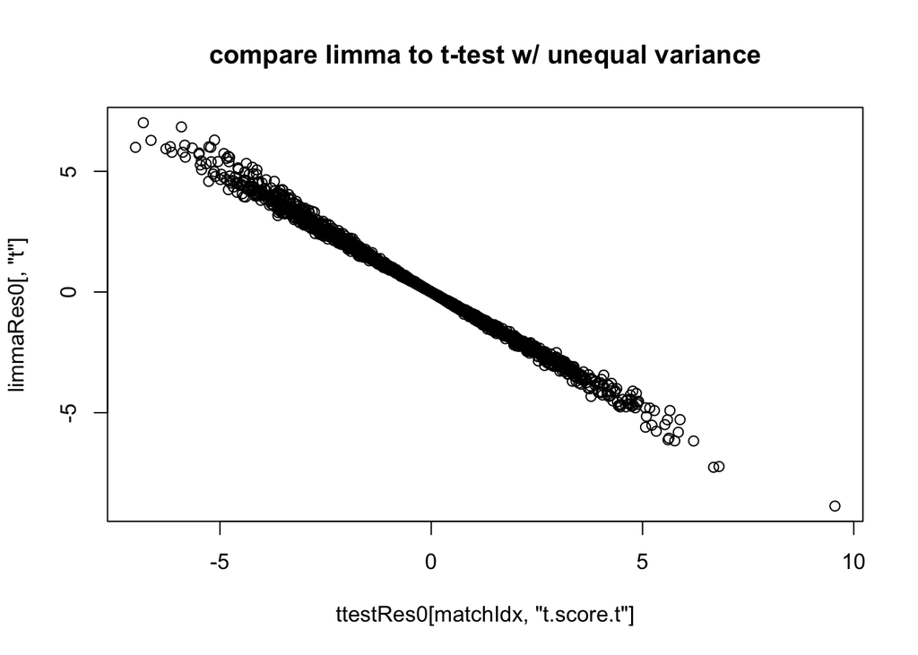

```r
## compare to t.test (with unequal variance)
if ( any(is.na(matchIdx <- match(rownames(limmaRes0),rownames(ttestRes0)))) ) stop('mismatch')
plot(ttestRes0[matchIdx,"t.score.t"],limmaRes0[,"t"],main="compare limma to t-test w/ unequal variance")
```

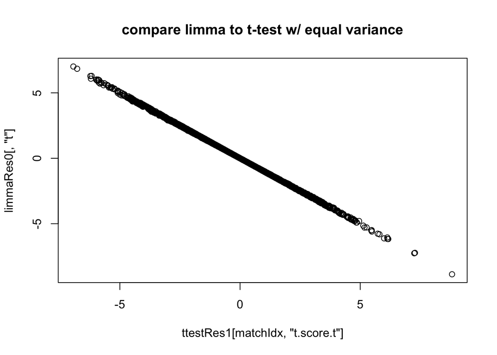

```r
## compare to t.test (with equal variance)
if ( any(is.na(matchIdx <- match(rownames(limmaRes0),rownames(ttestRes1)))) ) stop('mismatch')
plot(ttestRes1[matchIdx,"t.score.t"],limmaRes0[,"t"],main="compare limma to t-test w/ equal variance")
```

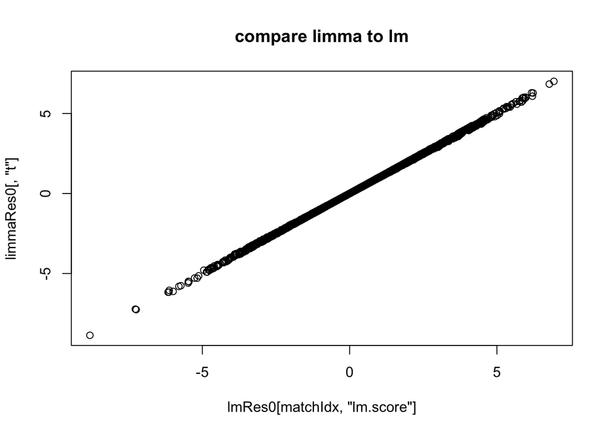

```r
## compare to lm
if ( any(is.na(matchIdx <- match(rownames(limmaRes0),rownames(lmRes0)))) ) stop('mismatch')
plot(lmRes0[matchIdx,"lm.score"],limmaRes0[,"t"],main="compare limma to lm")
```

# Task 6: Controlling for confounders

Repeat the differential analysis using limma, while controlling for the potentially confounding effect of genotoxicity, and save the results in a data frame names limmaRes1. Compare the results to the ones obtained with lm, by plotting the t-scores returned by the two methods.

```r
## get full differential expression output table, sorted by p-value
## <last command to fit a limma model>

design1 <- model.matrix( ~ carc + GenTox, data = pData(dat) )
colnames(design1) <- c("NON_CARC","CARCINOGEN", "GENTOX")      # let's simplify column names
fit1 <- lmFit(dat,design1) # fitting of linear model
fit1 <- eBayes(fit1)
limmaRes1 <- topTable(fit1, coef="CARCINOGEN", adjust.method="BH", n=Inf, sort.by="P")
saveRDS(limmaRes1, file=file.path(paste0(getwd(), "/limmaRes1.RDS")))
```

```r
head(limmaRes1)
```

```
##                        OldID           description      logFC   AveExpr
## NUCB2  ENSRNOG00000020456_at ENSRNOG00000020456_at -0.6720173 10.295950
## GPR146 ENSRNOG00000001288_at ENSRNOG00000001288_at -0.6234958  8.255686
## TMED3  ENSRNOG00000013889_at ENSRNOG00000013889_at -0.7566035  8.367773
## POLG2  ENSRNOG00000013728_at ENSRNOG00000013728_at -0.6774739  8.948459
## FADS3  ENSRNOG00000020385_at ENSRNOG00000020385_at  0.7205890  6.046457
## PALD1  ENSRNOG00000000561_at ENSRNOG00000000561_at -0.5655438  8.792916
##                t      P.Value    adj.P.Val         B
## NUCB2  -8.647808 6.125940e-14 1.225188e-10 21.021709
## GPR146 -6.909317 3.766859e-10 3.766859e-07 12.798617
## TMED3  -6.575969 1.875660e-09 1.230444e-06 11.285545
## POLG2  -6.518965 2.460888e-09 1.230444e-06 11.029680
## FADS3   6.077807 1.948533e-08 7.794133e-06  9.081495
## PALD1  -5.932917 3.792636e-08 1.129034e-05  8.455109
```

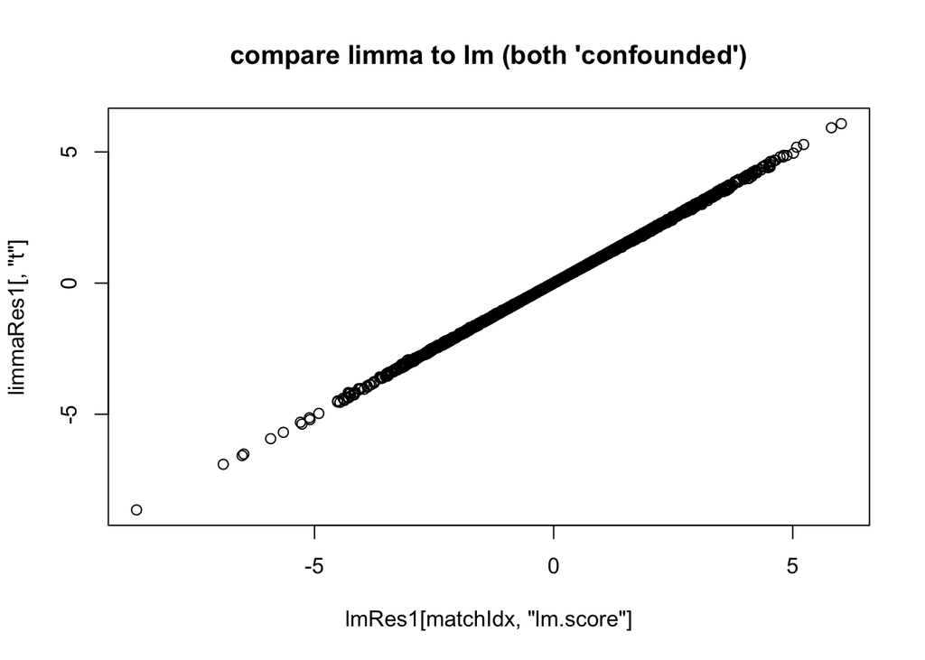

```r
## compare to lm with confounder
if ( any(is.na(matchIdx <- match(rownames(limmaRes1),rownames(lmRes1)))) ) stop('mismatch')
plot(lmRes1[matchIdx,"lm.score"],limmaRes1[,"t"],main="compare limma to lm (both 'confounded')")
```

```r
## how big/small are the differences (show the quantiles)?
cat("How big/small are the differences (show the quantiles)?\n")
```

```
## How big/small are the differences (show the quantiles)?
```

```r
cat("The differences are minute when comparing the results from a linear model
    to a limma model and this is because they are both using a linear model
    against the dataset.
    As shown below, the IQR for 0, 25%, 50%, 75%, 100% percentiles have a small
    spread and the data in general is clustered around the median.")
```

```
## The differences are minute when comparing the results from a linear model
##     to a limma model and this is because they are both using a linear model
##     against the dataset.
##     As shown below, the IQR for 0, 25%, 50%, 75%, 100% percentiles have a small
##     spread and the data in general is clustered around the median.
```

```r
quantile(lmRes1[matchIdx,"lm.score"]-limmaRes1[,"t"])
```

```
##            0%           25%           50%           75%          100%
## -0.1207140974 -0.0086299366 -0.0001921069  0.0079242706  0.1097938614
```

# Task 7: Heatmap

Finally, we generate a heatmap of the top markers (FDR ≤ 0.01 in either direction).

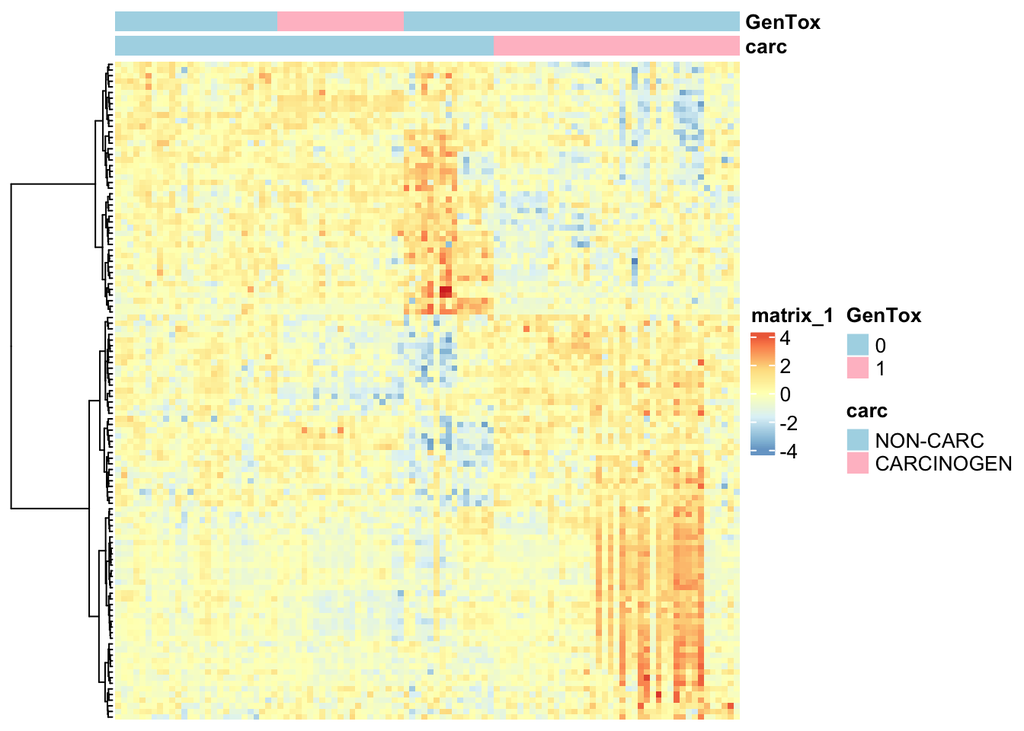

```r
chemPalette <- c("lightblue", "pink")
max_fdr <- 0.01
markers <- lmRes1[,"lm.fdr"] <= max_fdr
dat_heatmap <- dat[markers == TRUE, ]
annot <- pData(dat_heatmap)[, c("carc", "GenTox")]
annot$GenTox <- as.factor(annot$GenTox)
annotCol <- list(
  carc = chemPalette,
  GenTox = chemPalette
)
names(annotCol$carc) <- c("NON-CARC","CARCINOGEN")
names(annotCol$GenTox) <- c("0","1")
dat_heatmap <- dat_heatmap[, order(dat_heatmap$carc, decreasing = FALSE)]
pheatmap( exprs(dat_heatmap),
         annotation_col = annot,
         annotation_colors = annotCol,
         clustering_method = "ward.D", # default is 'complete'
         show_rownames = FALSE,
         show_colnames = FALSE,
         cluster_cols = FALSE,
         cluster_rows = TRUE,
         scale = "row",  # Scale the data by row (genes)
         )
```

Using limmaRes1 to detect which genes are up-regulated vs down-regulated. The reason for this, as stated above in task 4, a model with more information about the effects of chemicals on gene expression introduces less bias to the outcome.

```r
limmaRes1 <- limmaRes1[markers == TRUE, ]
up <- sum(limmaRes1$logFC >= 0)
down <- sum(limmaRes1$logFC <= 0)
c("up" = up, "down" = down)
```

```
##   up down
##   59   58
```